# PISA Math Analysis Round 1

Robert Glorioso

11/13/2014

Let’s look at how 15 year olds throughout the world feel about learning. Our data comes from the Programme for International Student Assessment (PISA). Information about this organization is located at http://www.oecd.org/pisa/pisaproducts/. Here is an R script to get this data into R:

```r
library(dplyr)
library(XML)
htmlTreeParse("http://beta.icm.edu.pl/PISAcontest/data/", useInternalNodes = T) %>%
  xmlRoot %>%
  xpathApply("//a", xmlGetAttr, "href") %>%
  lapply(function(i) download.file(paste0("http://beta.icm.edu.pl/PISAcontest/data/", i), paste0(".",i)))
```

The above code will download the PISA dataset files to your current working directory.

We are most interested in the student2012 data. This is a medium sized dataset (2.7 gb). It contains 485490 observations of 635 variables. We will work with a subset of the data - students in North America:

```r
load("student2012.rda")
load("student2012dict.rda")
student2012 = student2012[student2012$CNT %in% c("Florida (USA)","Connecticut (USA)", "Massachusetts (USA)", "Canada", "Mexico"),]
student2012dict = as.data.frame(sapply(student2012dict, as.character), stringsAsFactors = F) #removes factors for printing
```

Column names are encoded. A function to access the meaning of a column names is helpful:

```r
colDecode = function(colName){
  if(!is.numeric(colName)) colName = which(student2012dict[,1] == colName)
  if(length(colName) == 0 || colName < 1 || colName > 635) stop("Invalid Column")
  if(!is.factor(student2012[,colName])) cat(student2012dict[colName,], "\nQuantiles:\n",quantile(student2012[,colName], na.rm = T), "\n")
    else cat(student2012dict[colName,1], "\n", student2012dict[colName,2], "\nFactor Levels:\n", paste(levels(student2012[,colName]), collapse = "\n"), "\n")
}
colDecode(67)
```

```
## ST29Q01
##  Math Interest - Enjoy Reading
## Factor Levels:
##  Agree
## Disagree
## Strongly agree
## Strongly disagree
```

```r
colDecode(69)
```

```
## ST29Q03
##  Math Interest - Look Forward to Lessons
## Factor Levels:
##  Agree
## Disagree
## Strongly agree
## Strongly disagree
```

```r
colDecode(70)
```

```
## ST29Q04
##  Math Interest - Enjoy Maths
## Factor Levels:
##  Agree
## Disagree
## Strongly agree
## Strongly disagree
```

We’ll make a linear model with these three variables as the predictors:

```r
mathLM1 = lm(PV1MATH ~ ST29Q01 + ST29Q03 + ST29Q04, data = student2012)
summary(mathLM1)
```

```
##
## Call:
## lm(formula = PV1MATH ~ ST29Q01 + ST29Q03 + ST29Q04, data = student2012)
##
## Residuals:
##     Min      1Q  Median      3Q     Max
## -309.19  -63.75   -4.83   59.57  353.47
##
## Coefficients:
##                          Estimate Std. Error t value Pr(>|t|)
## (Intercept)              454.9642     0.8775 518.490  < 2e-16 ***
## ST29Q01Disagree           11.1687     1.1777   9.483  < 2e-16 ***
## ST29Q01Strongly agree     -5.2385     1.8578  -2.820  0.00481 **
## ST29Q01Strongly disagree  -1.1988     1.7750  -0.675  0.49945
## ST29Q03Disagree           23.8112     1.1941  19.941  < 2e-16 ***
## ST29Q03Strongly agree    -11.3824     1.6023  -7.104 1.23e-12 ***
## ST29Q03Strongly disagree  33.3580     2.0480  16.288  < 2e-16 ***
## ST29Q04Disagree          -19.7692     1.2234 -16.159  < 2e-16 ***
## ST29Q04Strongly agree     30.2062     1.7497  17.264  < 2e-16 ***
## ST29Q04Strongly disagree -23.0638     1.9679 -11.720  < 2e-16 ***
## ---
## Signif. codes:  0 '***' 0.001 '**' 0.01 '*' 0.05 '.' 0.1 ' ' 1
##
## Residual standard error: 90.3 on 42695 degrees of freedom
##   (22939 observations deleted due to missingness)
## Multiple R-squared:  0.02565,    Adjusted R-squared:  0.02545
## F-statistic: 124.9 on 9 and 42695 DF,  p-value: < 2.2e-16
```

Notice that the level “agree” is missing from the summary. That is because a linear model will absorb the first level of a categorical variable into the intercept term. We have to keep this in mind when interpreting the coefficients.

We look at the first variable “Math Interest - Enjoy Reading”. It looks like there’s an increase of 11 points in the score of those who answer “disagree” from those who answered “agree”. We can examine a plot of this data to visualize the trend.

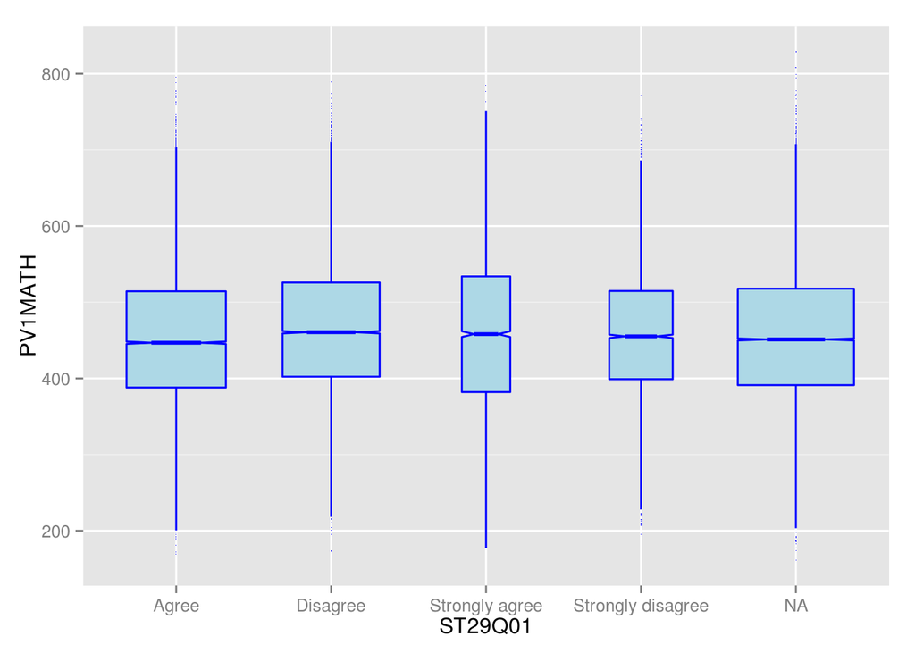